# Trending themes screener: From Today’s Macro Narrative to US Equity Exposure

This notebook reverses the usual thematic workflow. It starts with the most important macro events in the rolling last 24 hours, consolidates them into investable themes, grounds those themes with [Bigdata.com](https://bigdata.com), and then maps the highest-ranked theme to US mid- and large-cap equities.

The output is a reproducible daily snapshot:

`as-of date → ranked themes → daily theme attention/sentiment → company exposure evidence`

## Environment

Run from the `Thematic_Screener_CLI` project with the `uv` Jupyter environment. Credentials are read from `.env`: `BIGDATA_API_KEY`, `OPENAI_API_KEY`, and the four `SNOWFLAKE_*` variables. No credential value is stored in this notebook.

```python
from __future__ import annotations

import json
import os
import textwrap
from datetime import UTC, date, datetime
from pathlib import Path

import pandas as pd
from dotenv import load_dotenv
from IPython.display import display

from src import screener, viz
from src.derivative_grounding import collect_grounding, format_grounding_brief, write_grounding
from src.derivative_taxonomy import derivative_preview, validate_derivatives_taxonomy
from src.modes import AnalysisMode, get_profile
from src.notebook_support import display_figure, preview_quote, quiet_output
from src.prompts import TAXONOMY_STYLE_DERIVATIVES
from src.run_context import RunContext
from src.theme_timeseries import (
    build_company_exposure_daily,
    build_exposure_aggregate_daily,
    fetch_theme_volume,
)
from src.trending_themes import demo_lookback_window, discover_theme_candidates

PROJECT_ROOT: Path = Path.cwd()
if PROJECT_ROOT.name == "notebooks":
    PROJECT_ROOT = PROJECT_ROOT.parent
os.chdir(PROJECT_ROOT)
load_dotenv(PROJECT_ROOT / ".env")

%matplotlib inline
pd.set_option("display.max_colwidth", 120)
```

## 1. Define the as-of date and US equity perimeter

The universe contains the US mid- and large-cap entities to which the selected theme will be mapped. The discovery date is explicit so a completed run can be reproduced.

```python
AS_OF_DATE: date = datetime.now(UTC).date()
UNIVERSE_PATH: Path = PROJECT_ROOT / "us_ml_caps.csv"
RETRIEVAL_DEPTH: float = 0.05
MODE: str = AnalysisMode.THEMATIC_SCREENER.value

universe_df: pd.DataFrame = screener.load_universe(UNIVERSE_PATH)
company_ids: list[str] = universe_df[screener.UNIVERSE_ID_COLUMN].tolist()

print(f"As-of date: {AS_OF_DATE}")
print(f"Universe: {len(universe_df):,} US mid/large-cap companies")
display(universe_df.head(10))
```

```
As-of date: 2026-09-01
Universe: 985 US mid/large-cap companies
```

|  | RP_ENTITY_ID | COMPANY_NAME |
| --- | --- | --- |
| 0 | 9E5C2C | Sumisho Air Lease Corp. |
| 1 | 9E91C6 | Wynn Resorts Ltd. |
| 2 | 9EA947 | Allison Transmission Holdings Inc. |
| 3 | 9F03CF | Hershey Co. |
| 4 | 9F18FA | TransDigm Group Inc. |
| 5 | 9F47E2 | Roku Inc. |
| 6 | 9F4A7D | EnLink Midstream LLC |
| 7 | 9F6B1A | Labcorp Holdings Inc. |
| 8 | 9F71E5 | Intercontinental Exchange Inc. |
| 9 | 9FA83B | Performance Food Group Co. |

## 2. Discover today’s macro themes

Snowflake ranks the rolling last 24 hours of non-company RavenPack events by source breadth, persistence, sentiment magnitude, language breadth, and fact quality. An LLM merges duplicate story angles, removes weak market narratives, and creates focused search queries. Those candidate themes are then checked against recent Bigdata.com evidence before final ranking.

```python
with quiet_output():
    macro_events, grounded_themes, theme_candidates = discover_theme_candidates(
        as_of_date=AS_OF_DATE
    )

macro_events_df: pd.DataFrame = pd.DataFrame(
    [event.model_dump(mode="json") for event in macro_events]
)
candidates_df: pd.DataFrame = pd.DataFrame(
    [candidate.model_dump(mode="json") for candidate in theme_candidates]
)

display(macro_events_df.loc[:, ["importance", "entity_name", "category", "sent", "sample_title"]])
display(candidates_df.assign(rank=range(1, len(candidates_df) + 1)).set_index("rank"))
```

```
2026-09-01 14:26:45,684 - INFO - Snowflake Connector for Python Version: 4.7.2, Python Version: 3.13.5, Platform: macOS-26.6.2-arm64-arm-64bit-Mach-O
```

```
2026-09-01 14:26:45,685 - INFO - Connecting to GLOBAL Snowflake domain
```

```
2026-09-01 14:26:45,762 - INFO - Found credentials in shared credentials file: ~/.aws/credentials
```

|  | importance | entity_name | category | sent | sample_title |
| --- | --- | --- | --- | --- | --- |
| 0 | 3.997377 | Government of the Russian Federation | violent-attack-attacker | -1.00 | Russia Kills 12 on 6th Consecutive Night of Attacks on Kyiv |
| 1 | 3.986438 | Grand Canyon National Park | flood | -0.92 | At least 2 dead after flash flooding tears through Grand Canyon |
| 2 | 3.077889 | New York City | violent-attack-target | -0.83 | Urgent: Woman shot by police after stabbing 2 people near New York's Times Square: media |
| 3 | 3.006570 | Ukraine | violent-attack-target | -0.99 | Death toll rises to 38 from Russia's deadliest attack on Ukraine this year |
| 4 | 2.928849 | Kiev, Ukraine | violent-attack-target | -0.83 | Russia struck Kyiv for the fifth consecutive day to damage its warehouses and empty supermarket shelves |
| 5 | 2.889664 | Government of Iran | violent-attack-attacker | -0.84 | Iran Attacks US Bases US in Jordan in retaliation for Washington bombing in Larak. |
| 6 | 2.884272 | Grand Canyon, US | flood | -0.92 | Nearly 80 people rescued in Grand Canyon flooding, 2 others died and 1 is unaccounted for, officials say |
| 7 | 2.795121 | Crude Oil | commodity-price-gain | 0.53 | Bond sell-off heats up as oil prices continue to rise |
| 8 | 2.742513 | Iran | violent-attack-target | -0.99 | US and Iran trade strikes for first time in weeks |
| 9 | 2.730213 | Eurozone | inflation-up | -0.77 | Inflation in the eurozone soared to 3.3% in August, the highest in three years |

| rank | main_theme | analyst_focus | rationale | search_queries |
| --- | --- | --- | --- | --- |
| 1 | Middle East supply shock favors energy over broad equities | Screen U.S. energy producers, refiners, oil-services companies, fuel-sensitive businesses, and internationally expos... | This has the strongest and most immediate evidence: renewed U.S.-Iran strikes and tanker incidents near the Strait o... | [U.S.-Iran strikes Strait of Hormuz Brent crude above $90 impact on U.S. equities, higher oil prices geopolitical te... |
| 2 | Geopolitical inflation shock raises U.S. rates and equity-duration risk | Assess valuation and earnings sensitivity across long-duration growth, technology, consumer discretionary, rate-sens... | The supplied evidence repeatedly links renewed hostilities and higher crude prices with inflation fears, Treasury-yi... | [oil price surge Treasury yields Fed rate hike expectations U.S. stocks August September 2026, geopolitical oil shoc... |
| 3 | Ukraine escalation increases defense, infrastructure-repair, and supply-chain risk | Screen U.S. defense contractors and suppliers alongside companies exposed to ports, rail, logistics, agriculture, fo... | The rows describe repeated strikes on Ukrainian rail infrastructure, ports, warehouses, grain shipments, energy faci... | [Ukraine strikes rail depots ports warehouses energy infrastructure defense spending implications, Russia Ukraine at... |
| 4 | Energy-driven European inflation increases ECB tightening and global risk-premium pressure | Evaluate U.S. multinationals with European revenue, exporters, discretionary businesses, banks, and defensive cash-g... | Eurozone inflation accelerated from 2.9% to 3.3% in August, with the supplied sources attributing the increase large... | [Eurozone inflation 3.3% August 2026 energy prices ECB rate hike U.S. equities, ECB tightening European bond selloff... |

### Grounding behind the candidate list

The preview below keeps source, date, headline, URL, and only a short excerpt. Full passages remain in the run artifacts and are not embedded in the committed notebook.

```python
grounding_rows: list[dict[str, object]] = [
    {
        "theme": grounded.seed.main_theme,
        "query": source.query,
        "source": source.source_name,
        "date": source.timestamp[:10],
        "headline": source.headline,
        "url": source.url,
        "passage": preview_quote(source.text),
    }
    for grounded in grounded_themes
    for source in grounded.sources
]
grounding_sources_df: pd.DataFrame = pd.DataFrame(grounding_rows)
display(grounding_sources_df)
```

|  | theme | query | source | date | headline | url | passage |
| --- | --- | --- | --- | --- | --- | --- | --- |
| 0 | Middle East supply shock favors energy over broad equities | U.S.-Iran strikes Strait of Hormuz Brent crude above $90 impact on U.S. equities | PubT | 2026-09-01 | Siebert Financial Corporation - Recession Cures Inflation. But Does This Inflation Need a Recession | https://blog.siebert.com/recession-cures-inflation.-but-does-this-inflation-need-a-recession | YESTERDAY'S MARKETS Yesterday, the S&P 500 fell 0.33%, while the Dow Jones Industrial Average … |
| 1 | Middle East supply shock favors energy over broad equities | U.S.-Iran strikes Strait of Hormuz Brent crude above $90 impact on U.S. equities | Financial Times | 2026-09-01 | Saudi and South Korean oil tankers hit in Strait of Hormuz | https://www.ft.com/content/bbbce2e1-6542-4806-9c26-d35e8c3b702e | That vessel had been transiting the strait via the route closest to the Omani … |
| 2 | Middle East supply shock favors energy over broad equities | U.S.-Iran strikes Strait of Hormuz Brent crude above $90 impact on U.S. equities | Alliance News | 2026-09-01 | JOHANNESBURG MARKET MIDDAY: Stocks struggle on conflict worries |  | Late Sunday, the US said it had carried out strikes on Iran's Larak island … |
| 3 | Middle East supply shock favors energy over broad equities | U.S.-Iran strikes Strait of Hormuz Brent crude above $90 impact on U.S. equities | Benzinga | 2026-09-01 | Scott Bessent Warns Iran Economy Could Collapse 'Within Weeks or Months' as US Turns Up Pressure: Says Goal Is to Ma... | https://www.benzinga.com/node/61539717?utm_campaign=partner_feed&utm_medium=feed&utm_source=ravenpack | Iran is already under severe pressure. Reuters had separately reported on Saturday that President … |
| 4 | Middle East supply shock favors energy over broad equities | U.S.-Iran strikes Strait of Hormuz Brent crude above $90 impact on U.S. equities | Finwire | 2026-09-01 | Tanker hit in Strait of Hormuz - fears of renewed escalation |  | A tanker was hit by three unidentified projectiles in the Strait of Hormuz on … |
| ... | ... | ... | ... | ... | ... | ... | ... |
| 57 | Energy-driven European inflation increases ECB tightening and global risk-premium pressure | European energy inflation higher rates sector implications for U.S. large-cap companies | Quartr Reports | 2026-08-14 | SFC Energy AG: Q2 2026 Earnings Call on Aug 14, 2026 - Report | https://files.quartr.com/reports/3fc8f4c7d15480fb1fd1a7c9fef3dc5b-2026-08-14-05-22-07.pdf?ref=UmF2ZW5QYWNr | The ongoing boom in spending on artificial intelligence remained a major driver of the … |
| 58 | Energy-driven European inflation increases ECB tightening and global risk-premium pressure | European energy inflation higher rates sector implications for U.S. large-cap companies | PubT | 2026-08-24 | Union Bancaire Privee UBP SA - UBP Weekly View - Long-end yields climb to multi-decade highs; dollar and risk assets... | https://www.ubp.com/en/news-insights/newsroom/ubp-weekly-view-long-end-yields-climb-to-multi-decade-highs-dollar-and... | Global PMIs held up despite high energy costs, with inflation easing in the US … |
| 59 | Energy-driven European inflation increases ECB tightening and global risk-premium pressure | European energy inflation higher rates sector implications for U.S. large-cap companies | FXStreet News | 2026-09-01 | Silver drops below $65 as hawkish Fed bets weigh on XAG/USD |  | Rising energy prices add to inflation concerns. Tensions in the Middle East support Oil … |
| 60 | Energy-driven European inflation increases ECB tightening and global risk-premium pressure | European energy inflation higher rates sector implications for U.S. large-cap companies | PubT | 2026-08-17 | Union Bancaire Privee UBP SA - UBP Weekly View - US inflation looks past its peak, making a September Fed rate hold ... | https://www.ubp.com/en/news-insights/newsroom/ubp-weekly-view-us-inflation-looks-past-its-peak-making-a-september-fe... | This was also supported by a confluence of company-specific factors including SK Hynix setting … |
| 61 | Energy-driven European inflation increases ECB tightening and global risk-premium pressure | European energy inflation higher rates sector implications for U.S. large-cap companies | FXStreet News | 2026-08-21 | Euro sits near multi-month top vs weak USD as bulls await move beyond 1.1700 ahead of PMIs |  | According to Commerzbank, the increasingly tight balance in European gas storage "increases the pressure … |

62 rows × 7 columns

## 3. Select the first ranked theme

For this prototype the first candidate is selected mechanically. In a production daily process, the complete ranked list should be retained and screened subject to cost and portfolio relevance.

The search window is **not** an estimated start date for the theme. For this demo we look back one calendar year from the as-of date so the volume and exposure series have enough history to plot. When the selected theme actually began — and whether an earlier or shorter window would be more informative — is a separate investigation.

```python
selected_candidate = theme_candidates[0]
START_DATE_VALUE, END_DATE_VALUE = demo_lookback_window(end_date=AS_OF_DATE)
MAIN_THEME: str = selected_candidate.main_theme
ANALYST_FOCUS: str = selected_candidate.analyst_focus
START_DATE: str = START_DATE_VALUE.isoformat()
END_DATE: str = END_DATE_VALUE.isoformat()
RUN_NAME: str = f"reverse_us_{AS_OF_DATE:%Y%m%d}"

context: RunContext = RunContext.create(PROJECT_ROOT / "runs", RUN_NAME)
context.ensure_run_dir()
context.save_config(
    {
        "mode": MODE,
        "main_theme": MAIN_THEME,
        "analyst_focus": ANALYST_FOCUS,
        "universe": str(UNIVERSE_PATH),
        "start_date": START_DATE,
        "end_date": END_DATE,
        "taxonomy_style": TAXONOMY_STYLE_DERIVATIVES,
        "chunk_percentage": RETRIEVAL_DEPTH,
        "discovery_as_of": AS_OF_DATE.isoformat(),
        "lookback": "demo_one_year",
        "selected_candidate_rank": 1,
    }
)
(context.run_dir / "macro_events.json").write_text(
    json.dumps([event.model_dump(mode="json") for event in macro_events], indent=2),
    encoding="utf-8",
)
(context.run_dir / "theme_candidates.json").write_text(
    json.dumps(
        [candidate.model_dump(mode="json") for candidate in theme_candidates],
        indent=2,
    ),
    encoding="utf-8",
)
(context.run_dir / "candidate_grounding.json").write_text(
    json.dumps(
        [theme.model_dump(mode="json") for theme in grounded_themes],
        indent=2,
    ),
    encoding="utf-8",
)

print(f"MAIN_THEME: {MAIN_THEME}")
print(f"ANALYST_FOCUS: {ANALYST_FOCUS}")
print(f"Demo lookback window: {START_DATE} to {END_DATE} (not a theme onset date)")
print(f"Run directory: {context.run_dir.relative_to(PROJECT_ROOT)}")
```

```
MAIN_THEME: Middle East supply shock favors energy over broad equities
ANALYST_FOCUS: Screen U.S. energy producers, refiners, oil-services companies, fuel-sensitive businesses, and internationally exposed industrials for direct commodity, margin, and demand sensitivity.
Demo lookback window: 2025-09-01 to 2026-09-01 (not a theme onset date)
Run directory: runs/reverse_us_20260901
```

## 4. Measure the theme through time

Bigdata.com Search Volume returns daily document count, chunk count, and average sentiment for the selected search definition. The attention z-score compares each day with the *prior* 30-day document baseline, avoiding look-ahead in the displayed signal.

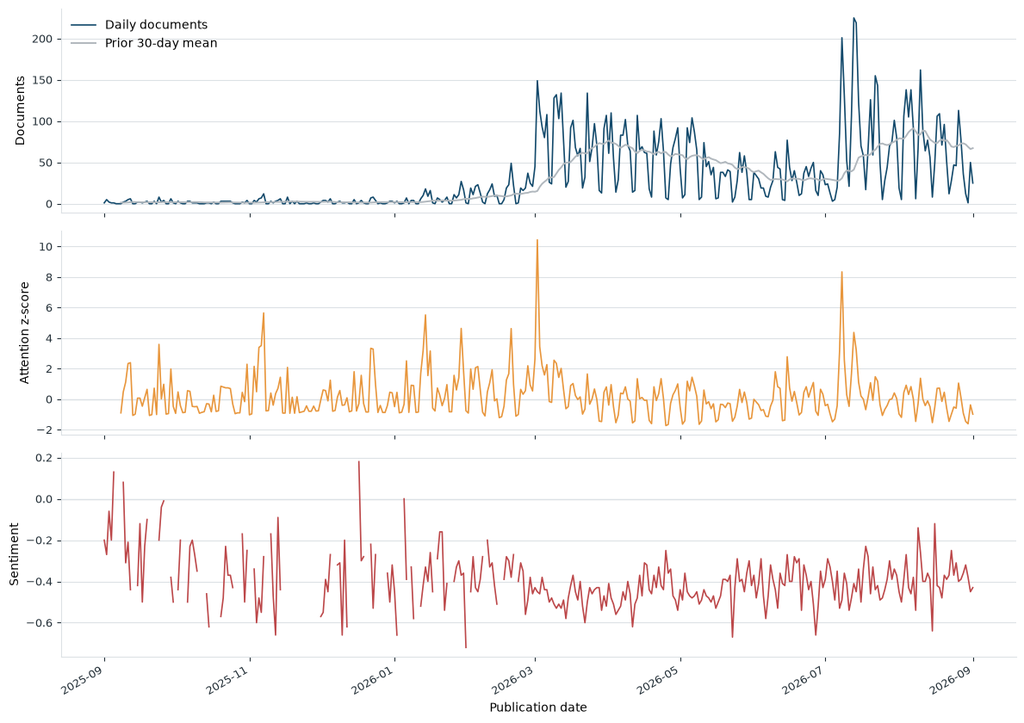

|  | date | documents | chunks | sentiment | documents_30d_mean | documents_30d_std | attention_zscore |
| --- | --- | --- | --- | --- | --- | --- | --- |
| 356 | 2026-08-23 | 28 | 29 | -0.25 | 69.266667 | 41.621255 | -0.991481 |
| 357 | 2026-08-24 | 47 | 60 | -0.37 | 68.566667 | 42.129707 | -0.511911 |
| 358 | 2026-08-25 | 46 | 52 | -0.31 | 69.966667 | 40.666516 | -0.589346 |
| 359 | 2026-08-26 | 113 | 135 | -0.40 | 70.566667 | 40.172697 | 1.056273 |
| 360 | 2026-08-27 | 78 | 82 | -0.39 | 72.866667 | 40.559202 | 0.126564 |
| 361 | 2026-08-28 | 36 | 43 | -0.36 | 73.133333 | 40.565776 | -0.915386 |
| 362 | 2026-08-29 | 12 | 12 | -0.32 | 71.833333 | 41.106434 | -1.455571 |
| 363 | 2026-08-30 | 1 | 1 | -0.38 | 68.866667 | 42.094127 | -1.612260 |
| 364 | 2026-08-31 | 50 | 67 | -0.45 | 66.233333 | 43.753616 | -0.371017 |
| 365 | 2026-09-01 | 25 | 33 | -0.43 | 67.266667 | 42.985217 | -0.983284 |

```python
theme_volume_df: pd.DataFrame = fetch_theme_volume(
    selected_candidate.search_queries,
    start_date=START_DATE_VALUE,
    end_date=END_DATE_VALUE,
)
theme_volume_df.to_csv(context.run_dir / "theme_volume_daily.csv", index=False)
display_figure(viz.plot_theme_attention_timeseries(theme_volume_df))
display(theme_volume_df.tail(10))
```

## 5. Translate the theme into exposure pathways

The selected theme now enters the established derivative workflow. Unfiltered market evidence grounds a strict first-, second-, and third-hop taxonomy before any company is scored.

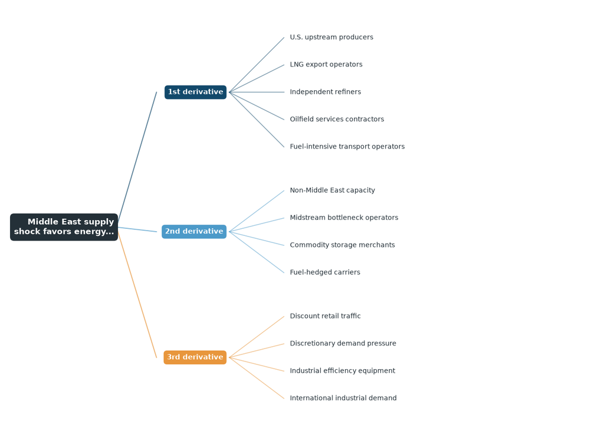

|  | hop | pathway |
| --- | --- | --- |
| 0 | 1st derivative | U.S. upstream producers |
| 1 | 1st derivative | LNG export operators |
| 2 | 1st derivative | Independent refiners |
| 3 | 1st derivative | Oilfield services contractors |
| 4 | 1st derivative | Fuel-intensive transport operators |
| 5 | 2nd derivative | Non-Middle East capacity |
| 6 | 2nd derivative | Midstream bottleneck operators |
| 7 | 2nd derivative | Commodity storage merchants |
| 8 | 2nd derivative | Fuel-hedged carriers |
| 9 | 3rd derivative | Discount retail traffic |
| 10 | 3rd derivative | Discretionary demand pressure |
| 11 | 3rd derivative | Industrial efficiency equipment |
| 12 | 3rd derivative | International industrial demand |

```python
profile = get_profile(AnalysisMode.THEMATIC_SCREENER)
with quiet_output():
    derivative_grounding: dict[str, object] = collect_grounding(
        MAIN_THEME,
        start_date=START_DATE,
        end_date=END_DATE,
        max_chunks_per_hop=8,
    )
write_grounding(context.grounding_path, derivative_grounding)
grounding_brief: str = format_grounding_brief(derivative_grounding)

with quiet_output():
    root = screener.generate_taxonomy(
        main_theme=MAIN_THEME,
        analyst_focus=ANALYST_FOCUS,
        profile=profile,
        taxonomy_style=TAXONOMY_STYLE_DERIVATIVES,
        grounding_brief=grounding_brief,
        print_taxonomy=False,
    )
validate_derivatives_taxonomy(root)
labels, search_queries = screener.write_taxonomy_artifacts(
    root,
    themes_path=context.themes_path,
    search_queries_path=context.search_queries_path,
    taxonomy_tree_path=context.taxonomy_tree_path,
    profile=profile,
)
preview_map: dict[str, list[str]] = derivative_preview(root)
context.derivative_preview_path.write_text(
    json.dumps(preview_map, indent=2),
    encoding="utf-8",
)
preview_rows: list[dict[str, str]] = [
    {"hop": hop, "pathway": pathway}
    for hop, pathways in preview_map.items()
    for pathway in pathways
]

display_figure(viz.plot_mindmap(root))
display(pd.DataFrame(preview_rows))
```

## 6. Plan and retrieve evidence across the US universe

Each leaf pathway becomes a search plan across all 985 companies. Inspect the expected chunk count before retrieval; `RETRIEVAL_DEPTH` is the fraction of that pool sampled. This run uses 5% as a denser demo pass.

```python
context.ensure_plans_dir()
with quiet_output():
    plan_paths: list[Path] = screener.build_plans(
        labels=labels,
        search_queries=search_queries,
        company_ids=company_ids,
        plans_dir=context.plans_dir,
        start_date=START_DATE,
        end_date=END_DATE,
    )
    plans_summary_df: pd.DataFrame = screener.summarize_plans(context.plans_dir)
print(screener.format_plans_summary(plans_summary_df))
print(f"Retrieval depth: {RETRIEVAL_DEPTH:.1%}")
```

```
Per-plan chunks:
  - The company sells value-priced groceries, consumables, and private-label merchandise to budget-conscious households.: 73,213
  - The company manufactures industrial products for international customers and reports regional orders, pricing, and input costs.: 52,792
  - The company sells apparel, home goods, or durable products to consumers and reports changes in discretionary demand.: 30,441
  - The company provides drilling, pressure pumping, completion, and well-construction services to exploration and production customers.: 28,496
  - The company transports, stores, and exports crude oil, natural gas, or refined products through pipelines and terminals.: 14,498
  - The company develops offshore or onshore production capacity outside major producing regions and markets barrels to global buyers.: 12,976
  - The company maintains fuel hedge contracts, fuel purchase agreements, or surcharge programs covering transportation consumption.: 10,836
  - The company liquefies natural gas and sells LNG cargoes to international utility and trading customers.: 10,765
  - The company consumes diesel, jet fuel, or marine fuel to transport passengers, freight, or cargo.: 10,137
  - The company sells industrial equipment, controls, or software that reduces customers' energy consumption and operating costs.: 9,137
  - The company purchases, stores, transports, and markets physical crude oil, natural gas, or refined products.: 8,032
  - The company purchases crude oil and operates refineries that produce gasoline, diesel, and jet fuel.: 6,745
  - The company produces crude oil and natural gas in U.S. shale and conventional fields.: 4,013
Total: 272,081
Retrieval depth: 5.0%
```

```python
context.ensure_results_dir()
with quiet_output():
    documents: list[dict[str, object]] = screener.run_search(
        plans_dir=context.plans_dir,
        chunk_percentage=RETRIEVAL_DEPTH,
    )
context.results_path.write_text(
    json.dumps(documents, indent=2, default=str),
    encoding="utf-8",
)
print(f"Retrieved and deduplicated documents: {len(documents):,}")
```

```
Retrieved and deduplicated documents: 8,149
```

## 7. Classify evidence and rank exposed companies

Retrieval finds candidate passages; the LLM classifier confirms whether each passage is genuine exposure evidence and assigns exactly one pathway. Counts measure breadth of confirmed evidence, while the relevance-weighted score used below is `retrieval relevance × absolute sentiment`.

```
Passages assessed: 10,408
Confirmed exposure evidence: 3,499
Companies with confirmed exposure: 405
```

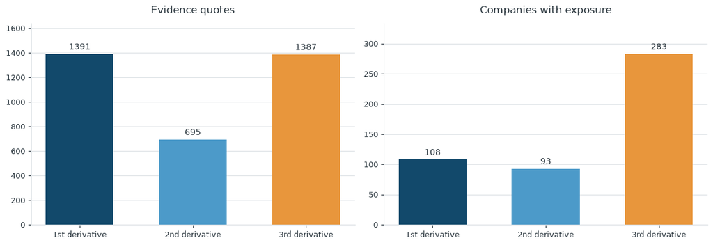

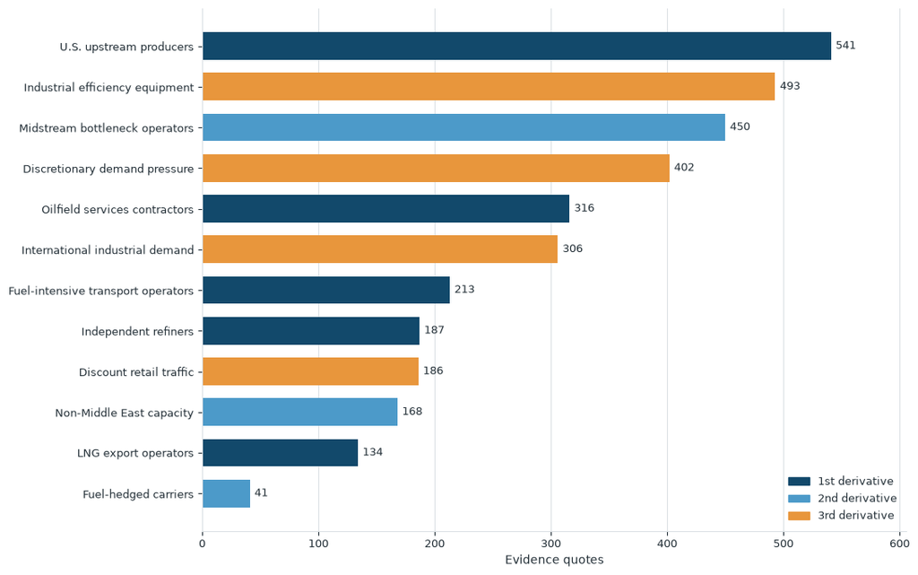

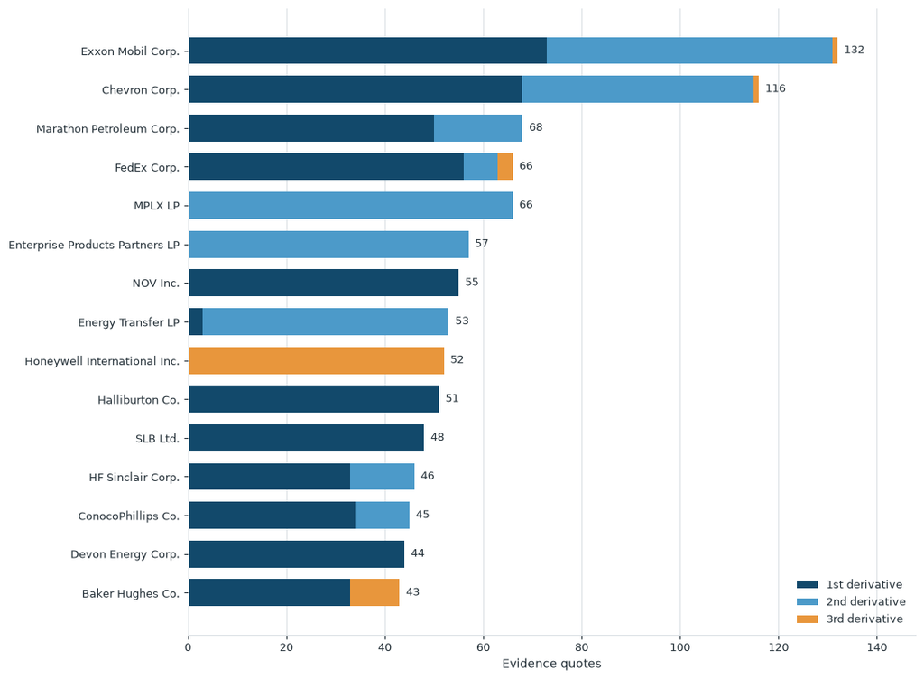

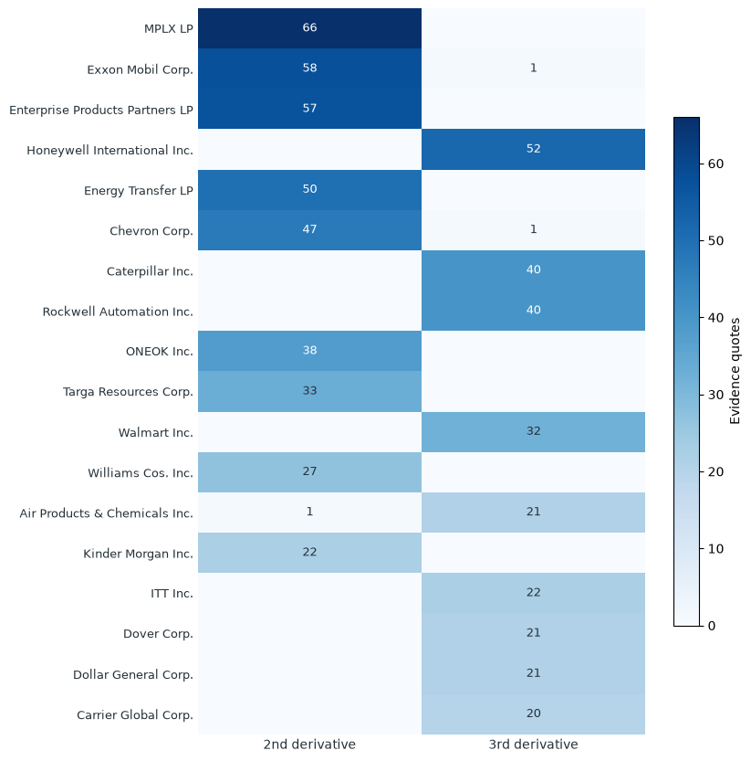

```python
sentences: list[dict[str, object]] = screener.extract_sentences(documents, universe_df)
with quiet_output():
    classifications: dict[str, dict[str, str]] = screener.label_sentences(
        sentences=sentences,
        main_theme=MAIN_THEME,
        analyst_focus=ANALYST_FOCUS,
        labels=labels,
        profile=profile,
        taxonomy_root=root,
    )
labeled_df: pd.DataFrame = screener.build_labeled_dataframe(sentences, classifications)
labeled_df.to_csv(context.labeled_sentences_path, index=False)
evidence_df: pd.DataFrame = viz.attach_hop_column(labeled_df, root)

print(f"Passages assessed: {len(sentences):,}")
print(f"Confirmed exposure evidence: {len(evidence_df):,}")
print(f"Companies with confirmed exposure: {evidence_df['company_name'].nunique():,}")
display_figure(viz.plot_hop_coverage(evidence_df))
display_figure(viz.plot_top_pathways(evidence_df))
display_figure(viz.plot_top_companies(evidence_df))
display_figure(viz.plot_company_hop_matrix(evidence_df, hops=viz.INDIRECT_HOPS))
```

## 8. Build the point-in-time exposure panel

The classified evidence is aggregated to the requested daily mapping. A row represents one company’s confirmed exposure to the selected theme on one publication date. The charts show aggregate exposure intensity, breadth, and the leading company trajectories.

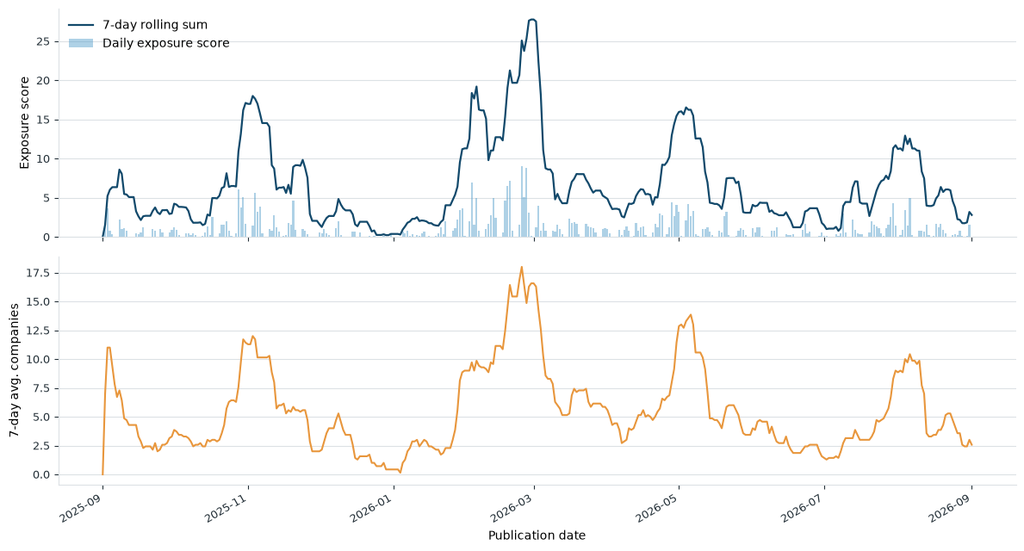

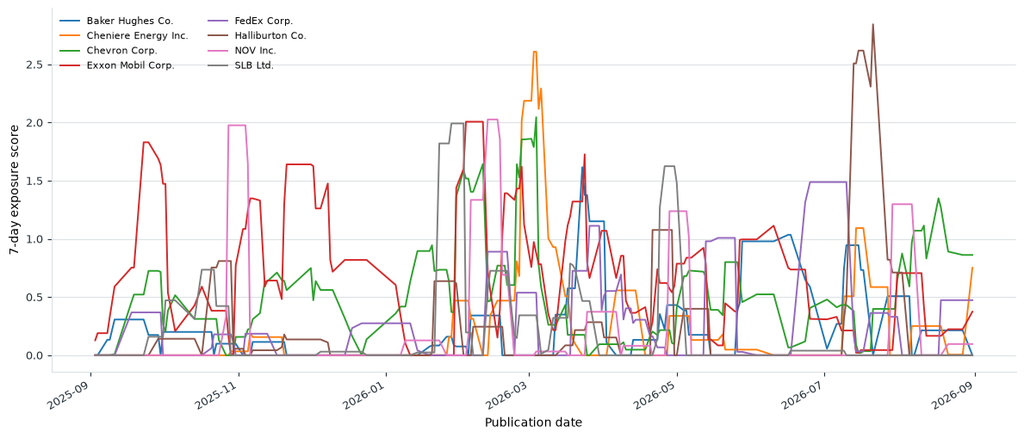

|  | date | theme | company_name | evidence_count | unique_documents | exposure_score | sentiment |
| --- | --- | --- | --- | --- | --- | --- | --- |
| 1987 | 2026-08-31 | Middle East supply shock favors energy over broad equities | Cheniere Energy Inc. | 3 | 3 | 0.746899 | 0.740 |
| 1988 | 2026-08-31 | Middle East supply shock favors energy over broad equities | ONEOK Inc. | 2 | 2 | 0.347192 | 0.635 |
| 1989 | 2026-08-31 | Middle East supply shock favors energy over broad equities | Cheniere Energy Partners L.P. | 1 | 1 | 0.283317 | 0.850 |
| 1990 | 2026-08-31 | Middle East supply shock favors energy over broad equities | Exxon Mobil Corp. | 1 | 1 | 0.150757 | -0.450 |
| 1991 | 2026-08-31 | Middle East supply shock favors energy over broad equities | Valero Energy Corp. | 1 | 1 | 0.050371 | -0.180 |
| 1992 | 2026-08-31 | Middle East supply shock favors energy over broad equities | Graco Inc. | 1 | 1 | 0.024085 | 0.180 |
| 1993 | 2026-08-31 | Middle East supply shock favors energy over broad equities | ConocoPhillips Co. | 1 | 1 | 0.000000 | 0.000 |
| 1986 | 2026-08-30 | Middle East supply shock favors energy over broad equities | ONEOK Inc. | 1 | 1 | 0.123586 | 0.650 |
| 1985 | 2026-08-28 | Middle East supply shock favors energy over broad equities | TJX Companies Inc. | 1 | 1 | 0.083929 | 0.400 |
| 1979 | 2026-08-27 | Middle East supply shock favors energy over broad equities | Dollar Tree Inc. | 2 | 2 | 0.287914 | 0.540 |
| 1980 | 2026-08-27 | Middle East supply shock favors energy over broad equities | Autodesk Inc. | 2 | 1 | 0.185100 | 0.480 |
| 1981 | 2026-08-27 | Middle East supply shock favors energy over broad equities | Best Buy Co. Inc. | 1 | 1 | 0.101676 | -0.550 |
| 1982 | 2026-08-27 | Middle East supply shock favors energy over broad equities | Targa Resources Corp. | 1 | 1 | 0.097047 | 0.550 |
| 1983 | 2026-08-27 | Middle East supply shock favors energy over broad equities | Chevron Corp. | 1 | 1 | 0.071582 | 0.250 |
| 1984 | 2026-08-27 | Middle East supply shock favors energy over broad equities | First Solar Inc. | 1 | 1 | 0.055593 | 0.350 |
| 1976 | 2026-08-26 | Middle East supply shock favors energy over broad equities | W.W. Grainger Inc. | 1 | 1 | 0.108952 | 0.790 |
| 1977 | 2026-08-26 | Middle East supply shock favors energy over broad equities | Caterpillar Inc. | 1 | 1 | 0.049630 | 0.160 |
| 1978 | 2026-08-26 | Middle East supply shock favors energy over broad equities | Albertsons Companies Inc. | 1 | 1 | 0.032219 | -0.200 |
| 1973 | 2026-08-25 | Middle East supply shock favors energy over broad equities | Carrier Global Corp. | 2 | 2 | 0.290352 | 0.570 |
| 1974 | 2026-08-25 | Middle East supply shock favors energy over broad equities | Williams Cos. Inc. | 1 | 1 | 0.064076 | 0.260 |
| 1975 | 2026-08-25 | Middle East supply shock favors energy over broad equities | Dick's Sporting Goods Inc. | 2 | 2 | 0.032271 | 0.015 |
| 1970 | 2026-08-24 | Middle East supply shock favors energy over broad equities | Walmart Inc. | 1 | 1 | 0.124264 | 0.490 |
| 1971 | 2026-08-24 | Middle East supply shock favors energy over broad equities | DoorDash Inc. | 1 | 1 | 0.112604 | 0.340 |
| 1972 | 2026-08-24 | Middle East supply shock favors energy over broad equities | Kroger Co. | 1 | 1 | 0.033089 | 0.140 |
| 1969 | 2026-08-23 | Middle East supply shock favors energy over broad equities | Occidental Petroleum Corp. | 1 | 1 | 0.014254 | -0.080 |
| 1968 | 2026-08-22 | Middle East supply shock favors energy over broad equities | The Wendy's Co. | 1 | 1 | 0.012294 | 0.110 |
| 1960 | 2026-08-21 | Middle East supply shock favors energy over broad equities | BJ's Wholesale Club Holdings Inc. | 2 | 2 | 0.108737 | 0.385 |
| 1961 | 2026-08-21 | Middle East supply shock favors energy over broad equities | NOV Inc. | 1 | 1 | 0.096420 | 0.410 |
| 1962 | 2026-08-21 | Middle East supply shock favors energy over broad equities | Kinder Morgan Inc. | 1 | 1 | 0.084442 | -0.470 |
| 1963 | 2026-08-21 | Middle East supply shock favors energy over broad equities | Jabil Inc. | 1 | 1 | 0.072880 | 0.630 |

```python
company_exposure_daily_df: pd.DataFrame = build_company_exposure_daily(
    evidence_df,
    theme=MAIN_THEME,
)
exposure_aggregate_daily_df: pd.DataFrame = build_exposure_aggregate_daily(
    company_exposure_daily_df,
    start_date=START_DATE_VALUE,
    end_date=END_DATE_VALUE,
)
company_exposure_daily_df.to_csv(
    context.run_dir / "company_exposure_daily.csv",
    index=False,
)
exposure_aggregate_daily_df.to_csv(
    context.run_dir / "exposure_aggregate_daily.csv",
    index=False,
)

display_figure(viz.plot_exposure_score_timeseries(exposure_aggregate_daily_df))
display_figure(viz.plot_top_company_exposure_timeseries(company_exposure_daily_df))
display(
    company_exposure_daily_df.sort_values(
        ["date", "exposure_score"], ascending=[False, False]
    ).head(30)
)
```

## 9. Company narratives and deliverables

The final LLM pass synthesizes each company’s confirmed evidence. Existing JSON and Excel exports are preserved, alongside the new discovery and daily time-series artifacts.

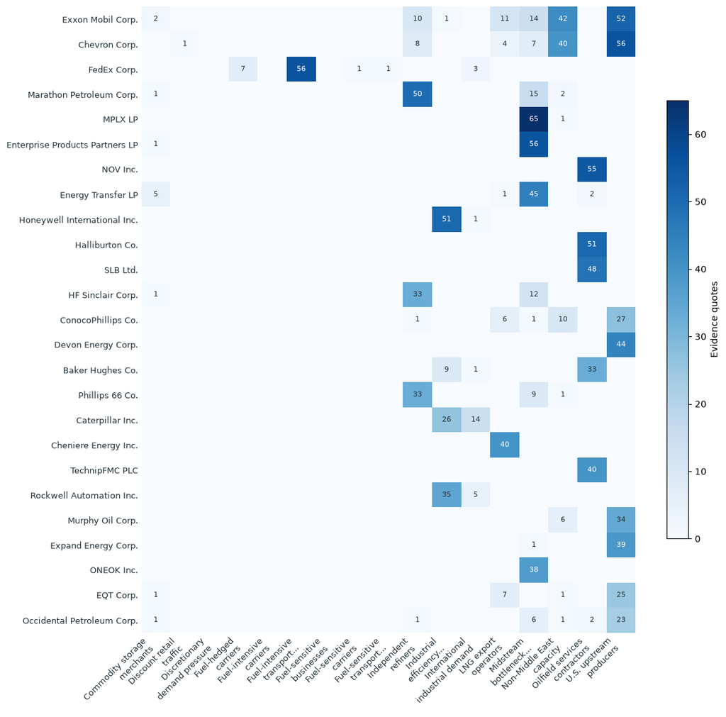

| label | company_name | Commodity storage merchants | Discount retail traffic | Discretionary demand pressure | Fuel-hedged carriers | Fuel-intensive carriers | Fuel-intensive transport operators | Fuel-sensitive businesses | Fuel-sensitive carriers | Fuel-sensitive transport operators | Independent refiners | Industrial efficiency equipment | International industrial demand | LNG export operators | Midstream bottleneck operators | Non-Middle East capacity | Oilfield services contractors | U.S. upstream producers | Composite Score |
| --- | --- | --- | --- | --- | --- | --- | --- | --- | --- | --- | --- | --- | --- | --- | --- | --- | --- | --- | --- |
| 0 | Exxon Mobil Corp. | 2 | 0 | 0 | 0 | 0 | 0 | 0 | 0 | 0 | 10 | 1 | 0 | 11 | 14 | 42 | 0 | 52 | 132 |
| 1 | Chevron Corp. | 0 | 1 | 0 | 0 | 0 | 0 | 0 | 0 | 0 | 8 | 0 | 0 | 4 | 7 | 40 | 0 | 56 | 116 |
| 2 | FedEx Corp. | 0 | 0 | 0 | 7 | 0 | 56 | 0 | 1 | 1 | 0 | 0 | 3 | 0 | 0 | 0 | 0 | 0 | 68 |
| 3 | Marathon Petroleum Corp. | 1 | 0 | 0 | 0 | 0 | 0 | 0 | 0 | 0 | 50 | 0 | 0 | 0 | 15 | 2 | 0 | 0 | 68 |
| 4 | MPLX LP | 0 | 0 | 0 | 0 | 0 | 0 | 0 | 0 | 0 | 0 | 0 | 0 | 0 | 65 | 1 | 0 | 0 | 66 |
| 5 | Enterprise Products Partners LP | 1 | 0 | 0 | 0 | 0 | 0 | 0 | 0 | 0 | 0 | 0 | 0 | 0 | 56 | 0 | 0 | 0 | 57 |
| 6 | NOV Inc. | 0 | 0 | 0 | 0 | 0 | 0 | 0 | 0 | 0 | 0 | 0 | 0 | 0 | 0 | 0 | 55 | 0 | 55 |
| 7 | Energy Transfer LP | 5 | 0 | 0 | 0 | 0 | 0 | 0 | 0 | 0 | 0 | 0 | 0 | 1 | 45 | 0 | 2 | 0 | 53 |
| 8 | Honeywell International Inc. | 0 | 0 | 0 | 0 | 0 | 0 | 0 | 0 | 0 | 0 | 51 | 1 | 0 | 0 | 0 | 0 | 0 | 52 |
| 9 | Halliburton Co. | 0 | 0 | 0 | 0 | 0 | 0 | 0 | 0 | 0 | 0 | 0 | 0 | 0 | 0 | 0 | 51 | 0 | 51 |
| 10 | SLB Ltd. | 0 | 0 | 0 | 0 | 0 | 0 | 0 | 0 | 0 | 0 | 0 | 0 | 0 | 0 | 0 | 48 | 0 | 48 |
| 11 | HF Sinclair Corp. | 1 | 0 | 0 | 0 | 0 | 0 | 0 | 0 | 0 | 33 | 0 | 0 | 0 | 12 | 0 | 0 | 0 | 46 |
| 12 | ConocoPhillips Co. | 0 | 0 | 0 | 0 | 0 | 0 | 0 | 0 | 0 | 1 | 0 | 0 | 6 | 1 | 10 | 0 | 27 | 45 |
| 13 | Devon Energy Corp. | 0 | 0 | 0 | 0 | 0 | 0 | 0 | 0 | 0 | 0 | 0 | 0 | 0 | 0 | 0 | 0 | 44 | 44 |
| 14 | Phillips 66 Co. | 0 | 0 | 0 | 0 | 0 | 0 | 0 | 0 | 0 | 33 | 0 | 0 | 0 | 9 | 1 | 0 | 0 | 43 |
| 15 | Baker Hughes Co. | 0 | 0 | 0 | 0 | 0 | 0 | 0 | 0 | 0 | 0 | 9 | 1 | 0 | 0 | 0 | 33 | 0 | 43 |
| 16 | Expand Energy Corp. | 0 | 0 | 0 | 0 | 0 | 0 | 0 | 0 | 0 | 0 | 0 | 0 | 0 | 1 | 0 | 0 | 39 | 40 |
| 17 | Caterpillar Inc. | 0 | 0 | 0 | 0 | 0 | 0 | 0 | 0 | 0 | 0 | 26 | 14 | 0 | 0 | 0 | 0 | 0 | 40 |
| 18 | Cheniere Energy Inc. | 0 | 0 | 0 | 0 | 0 | 0 | 0 | 0 | 0 | 0 | 0 | 0 | 40 | 0 | 0 | 0 | 0 | 40 |
| 19 | TechnipFMC PLC | 0 | 0 | 0 | 0 | 0 | 0 | 0 | 0 | 0 | 0 | 0 | 0 | 0 | 0 | 0 | 40 | 0 | 40 |
| 20 | Rockwell Automation Inc. | 0 | 0 | 0 | 0 | 0 | 0 | 0 | 0 | 0 | 0 | 35 | 5 | 0 | 0 | 0 | 0 | 0 | 40 |
| 21 | Murphy Oil Corp. | 0 | 0 | 0 | 0 | 0 | 0 | 0 | 0 | 0 | 0 | 0 | 0 | 0 | 0 | 6 | 0 | 34 | 40 |
| 22 | ONEOK Inc. | 0 | 0 | 0 | 0 | 0 | 0 | 0 | 0 | 0 | 0 | 0 | 0 | 0 | 38 | 0 | 0 | 0 | 38 |
| 23 | EQT Corp. | 1 | 0 | 0 | 0 | 0 | 0 | 0 | 0 | 0 | 0 | 0 | 0 | 7 | 0 | 1 | 0 | 25 | 34 |
| 24 | Occidental Petroleum Corp. | 1 | 0 | 0 | 0 | 0 | 0 | 0 | 0 | 0 | 1 | 0 | 0 | 0 | 6 | 1 | 2 | 23 | 34 |

```
Artifacts written to runs/reverse_us_20260901
```

```python
with quiet_output():
    company_summaries_df: pd.DataFrame = screener.summarize_companies(
        merged_df=labeled_df,
        main_theme=MAIN_THEME,
        profile=profile,
    )
company_summaries_df.to_csv(context.company_summaries_path, index=False)
screener_df: pd.DataFrame = screener.build_screener_dataframe(
    labeled_df,
    company_summaries_df,
)
screener_df.to_csv(context.screener_results_path, index=False)

report: dict[str, object] = screener.build_report_json(
    screener_df,
    root,
    universe_df,
    MODE,
)
context.report_json_path.write_text(
    json.dumps(report, indent=2, default=str),
    encoding="utf-8",
)
screener.export_excel(
    screener_df,
    company_summaries_df,
    root,
    context.report_excel_path,
)

scoring_df: pd.DataFrame = screener.build_company_scoring_df(screener_df)
display_figure(viz.plot_company_pathway_matrix(scoring_df))
display(scoring_df.head(25))
print(f"Artifacts written to {context.run_dir.relative_to(PROJECT_ROOT)}")
```

### Sample company narratives

A few confirmed exposures, written from the labelled evidence. The first names are those with the most quotes; the later ones are companies whose evidence is only second- or third-hop, so they would not show up in a conventional direct-theme screen. Full narratives for every scored name are in the Excel workbook.

```python
summary_lookup: dict[str, str] = dict(
    zip(company_summaries_df["company_name"], company_summaries_df["summary"], strict=False)
)
top_by_quotes = evidence_df["company_name"].value_counts().head(3)
first_hop_names = set(
    evidence_df.loc[~evidence_df["hop"].isin(viz.INDIRECT_HOPS), "company_name"]
)
indirect_mask = evidence_df["hop"].isin(viz.INDIRECT_HOPS) & ~evidence_df["company_name"].isin(
    first_hop_names
)
indirect_only = evidence_df.loc[indirect_mask, "company_name"].value_counts().head(2)
preview_names = list(dict.fromkeys([*top_by_quotes.index, *indirect_only.index]))

for company in preview_names:
    quote_count = int((evidence_df["company_name"] == company).sum())
    hops = sorted(set(evidence_df.loc[evidence_df["company_name"] == company, "hop"].dropna()))
    print(f"{company}  —  {quote_count} quotes  —  {', '.join(hops)}")
    narrative = summary_lookup.get(company, "No narrative generated.")
    print(textwrap.fill(str(narrative), width=100, initial_indent="  ", subsequent_indent="  "))
    print()
```

```
Exxon Mobil Corp.  —  132 quotes  —  1st derivative, 2nd derivative, 3rd derivative
  Exxon Mobil’s integrated portfolio provides substantial exposure to a Middle East supply shock
  through high-volume U.S. Permian production, growing Guyana and other non-Middle East oil and gas
  capacity, and major LNG export positions including Golden Pass. Higher commodity prices and
  tighter global supply could support upstream earnings, international crude and refined-product
  exports, LNG revenues, and trading opportunities, while low-cost projects, production growth,
  logistics integration, and drilling efficiencies strengthen margins. Its extensive refining, fuel-
  marketing, pipeline, terminal, and NGL infrastructure adds sensitivity to refined-product margins,
  throughput, and transportation tariffs, with conversion investments supporting higher-value
  distillate and lubricant output. However, Exxon also has material Middle East exposure through
  Qatar LNG and Saudi refining interests, and disruptions or reduced crude availability could
  pressure regional throughput and downstream results, particularly in Asia.

Chevron Corp.  —  116 quotes  —  1st derivative, 2nd derivative, 3rd derivative
  Chevron is strongly positioned for an energy supply shock through its integrated exposure to
  upstream oil and gas production, particularly large Permian, Bakken, Gulf of Mexico, and other
  U.S. assets, as well as significant non-Middle East capacity in Kazakhstan, Venezuela, Argentina,
  Africa, Australia, and elsewhere. Higher crude and gas prices can support substantial commodity-
  linked revenue, while Permian productivity, infrastructure optimization, low-cost Gulf of Mexico
  barrels, and selected tie-back projects provide efficiency and capital advantages. Its extensive
  pipeline, terminal, storage, rail, gathering, and export infrastructure adds fee-based and
  bottleneck exposure, while approximately 1.8 million barrels per day of refining capacity,
  diversified crude sourcing, and refined-product marketing provide direct throughput and margin
  sensitivity, including potential benefits from wider crude-product spreads and operational
  flexibility. Chevron also participates in LNG liquefaction, trading, transportation, and
  regasification, expanding U.S. LNG and NGL export exposure, alongside growing U.S. and European
  renewable-fuels capacity. Overall, the breadth of its production, logistics, refining, LNG, and
  alternative-fuel businesses gives Chevron substantial upside from tighter global energy markets,
  though refinery incidents, supply-chain disruptions, and prospective international projects remain
  operating or execution risks.

Marathon Petroleum Corp.  —  68 quotes  —  1st derivative, 2nd derivative
  Marathon Petroleum is primarily a large U.S. independent refiner, with substantial exposure to
  crude and feedstock availability and pricing, crack spreads, refinery utilization, and gasoline,
  diesel, jet-fuel, renewable-fuel, and LPG demand across domestic, export, retail, wholesale, and
  contract channels. A Middle East supply shock could tighten refined-product markets and support
  margins, particularly where domestic crude access, yield optimization, and added jet and
  specialty-gasoline capacity improve feedstock economics and product flexibility, although
  disruptions to crude supplies, transportation, or fuel demand remain risks. Its MPLX platform adds
  material midstream exposure through crude and refined-product pipelines, terminals, storage,
```

[output cut: 17 more lines]

```
  refiner.

Enterprise Products Partners LP  —  57 quotes  —  2nd derivative
  Enterprise Products Partners is a large North American midstream infrastructure operator with more
  than 50,000 miles of pipelines and extensive gathering, processing, fractionation, storage,
  terminal, marine, and export assets serving natural gas, NGLs, crude oil, refined products, and
  petrochemicals. Its fee-based, often contract-supported transportation and capacity services
  connect U.S., Canadian, Permian, Haynesville, Gulf Coast, refinery, and international markets,
  while hedging and marketing activities add some commodity-margin exposure. Expanding Bahia NGL,
  Permian gas-processing, LPG/NGL export, and related pipeline and terminal capacity should support
  throughput and utilization as U.S. supplies are redirected toward international markets; a
  prolonged Middle East or Strait of Hormuz disruption could therefore increase demand for its
  logistics and export infrastructure. The primary exposure is to potentially constrained energy-
  supply-chain capacity and associated revenue growth, with limited evidence of cost-efficiency
  benefits beyond possible scale economies.
```

## Interpretation and production extension

This notebook is a daily **snapshot**: it discovers themes as of the run date, then measures the selected theme over a **one-year demo lookback**. That window is a reporting convenience, not a claim about when the theme started. A fully point-in-time backtest must archive each day’s event inputs, prompts, candidate rankings, taxonomy, search definition, and exposure outputs, then evaluate only data available on that date.